# Running an nf-core Nextflow pipeline – part I

Week 11 – Lecture B

Author

Affiliations

Jelmer Poelstra

[CFAES Bioinformatics Core, Ohio State University](https://go.osu.edu/bioinformatics-core)

[Dept. of Plant Pathology, Ohio State University](https://plantpath.osu.edu)

Presented on

November 2, 2026

Page last modified

October 31, 2026

## 1 Before we get started

In this lecture and the next, we will cover how you can run a bioinformatics pipeline written in the Nextflow language and developed as part of the nf-core initiative. On this page, we’ll introduce nf-core pipelines and do a test run, and in part II, we’ll run the pipeline on the Garrigós et al. (2025) RNA-seq data.

### 1.1 Learning goals

Specifically, you will learn:

- Why you may want to use pipelines like those made by the nf-core initiative
- What the nf-core *rnaseq* pipeline does, and when you would want to use it
- How to do a test run of a pipeline
- The difference between general Nextflow options and pipeline-specific options
- How to change Nextflow settings with a configuration file
- How to interpret the progress log and output files of a pipeline run, including the distinction between a final output dir and a “work dir”
- How to restart a Nextflow pipeline run using the `-resume` option

### 1.2 Getting ready

If you no longer have the VS Code session from Lecture A running:

1. At https://ondemand.osc.edu, start a VS Code session in `/fs/ess/PAS3493/people/$USER`, with **4 cores** (you’ll need these for the pipeline’s test run).
2. In your VS Code terminal, go to your working dir for this week:

   ```bash
   cd week11
   ```

## 2 nf-core pipelines and the *rnaseq* pipeline

### 2.1 Why run (nf-core) pipelines?

In week 10, we talked about managing complex bioinformatics workflows, and the advantages that formal Workflow Management Systems like [Nextflow](https://www.nextflow.io/) (Di Tommaso et al. 2017) have over DIY pipelines based on e.g. shell scripts. While you can use Nextflow to build your own workflows from scratch, we will here cover how to run an existing, community-developed Nextflow pipeline.

This is well worth covering for two reasons:

- Available pipelines cover many types of omics data, so you may well be able to use one for your own research.
- Running such a pipeline is a bit different and more involved than running a typical piece of bioinformatics software. But when you know how to run one nf-core pipeline, it will be relatively straightforward to run others as well.

Recall from week 10 that the [“nf-core” initiative](https://nf-co.re/) (Ewels et al. 2020) has many pipelines available for various omics data analysis types. Here are their most popular pipelines — we will run *rnaseq*:

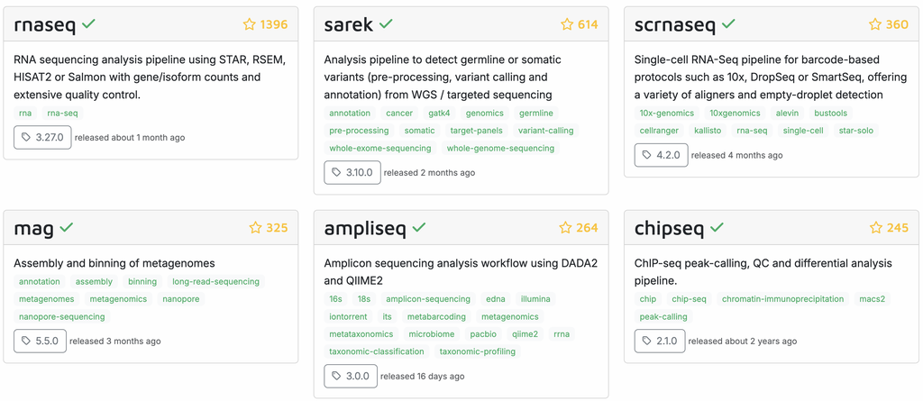

The 6 most popular nf-core pipelines as of October 2026

### 2.2 The nf-core *rnaseq* pipeline

The [nf-core *rnaseq* pipeline](https://nf-co.re/rnaseq) is meant for RNA-seq datasets like the one from Garrigós et al. (2025), where reads are aligned to a reference genome to produce gene-level counts[^1].

The inputs of this pipeline are FASTQ files with raw reads, and reference genome files (assembly & annotation), while the outputs include a gene count table that can be used for downstream differential expression analysis, and many “QC outputs”. Let’s take a closer look at the key steps in the pipeline — click on the image below to make it larger:

[figure not shown]

**Stage 1: Read QC and pre-processing**

- Read QC (FastQC)
- Adapter and quality trimming (TrimGalore or fastp)
- Optional removal of contaminants (BBSplit) and rRNA (SortMeRNA) — off by default, but we will include the latter

**Stage 2: Alignment & quantification**

- Alignment to the reference genome/transcriptome (STAR)
- Gene expression quantification (Salmon)

**Stages 3 and 4: Post-processing, QC, and reporting**

- Post-processing alignments: sort, index, mark duplicates (samtools, Picard)
- Alignment/count QC (RSeQC, Qualimap, dupRadar, Preseq, DESeq2)
- Create a QC/metrics report (MultiQC)

**TipCustomizing what the pipeline does *(Click to expand)**

This pipeline is quite flexible and you can turn several steps off, add optional steps, and change individual options for most tools that the pipeline runs.

- **Optional removal of contaminants** (BBSplit)  
  Map to 1 or more additional genomes whose sequences may be present as contamination, and remove reads that map better to contaminant genomes.
- **Alternative quantification routes**
  - Use RSEM instead of Salmon to quantify.
  - Skip STAR and perform direct pseudo-alignment & quantification with Salmon.
- **Transcript assembly and quantification (StringTie)**  
  While the pipeline is focused on gene-level quantification, it also assembles and quantifies transcripts with StringTie. This is run by default, but can be turned off.

### 2.3 Overview of running an nf-core pipeline

Here are some key aspects of running the nf-core *rnaseq* pipeline (and other nf-core pipelines) at OSC:

- We only need access to an **installation** of Nextflow. The pipeline runs all its constituent tools (FastQC, STAR, Salmon, etc.) via separate Apptainer containers that it will download for us.
- We can run the pipeline with a single command, `nextflow run [...]`. For our real run, the resulting main Nextflow process will **submit *many* Slurm batch jobs for us**, and orchestrate these until the pipeline has finished or failed. Because the pipeline can run for many hours, we will **submit the main process as a batch job** too.
- Nextflow **distinguishes between a final output dir and a “work dir”** (by default, `work`). All jobs run and produce outputs in sub-dirs of the work dir, and only a selection of their output files are copied to the final output dir[^2].
- Nextflow pipelines can be **restarted** using the `-resume` option, which will make them rerun only what is needed.

### 2.4 Test the Nextflow installation

We’ll use Nextflow via an OSC module and not via a container. That’s because Nextflow itself needs to submit Slurm jobs and run Apptainer containers, which is awkward from inside a container, where the `sbatch` and `apptainer` commands aren’t available. (The alternative is to use a Conda environment for Nextflow, but since a module is available at OSC, we will use that.)

We’ll start by finding and loading the Nextflow module. Then, we’ll do a test run of the nf-core *rnaseq* pipeline.

#### Exercise: Load the Nextflow module

We’ll run version 3.26.0 of the *rnaseq* pipeline, which requires Nextflow version 25.04.3 or later. Find the OSC Nextflow modules with a `module` command, and load one that is recent enough. Then, check which Nextflow version you’re running with `nextflow -v`.

## 3 Test-run the *rnaseq* pipeline

### 3.1 Introduction and setup

All nf-core pipelines can be test-run with a small test dataset that is included with the pipeline. Let’s perform such a test run to become familiar with the command syntax and the pipeline’s progress log and outputs.

Unlike our real run later on, we will run this test **interactively**, directly in our VS Code terminal, and Nextflow will *not* submit Slurm batch jobs. Instead, it will run all steps “locally”, on the compute node that our VS Code session runs on — which is why we asked for 4 cores for this session. This is a handy shortcut for a quick test run with a tiny dataset, but not the way to run a pipeline on real data.

```bash
mkdir testrun
cd testrun
```

### 3.2 Create a configuration file

The pipeline runs each tool in an Apptainer container that it downloads for us. To save time and storage space, we’ll use a shared dir with containers that I already downloaded. We’ll tell Nextflow about this dir in a [configuration (config) file](https://www.nextflow.io/docs/latest/config.html).

Config files contain settings for how Nextflow runs a pipeline, such as where to store containers and how to run jobs. Each pipeline comes with its own config file(s) with default settings, and you can add to or override those settings with your own config file. The simplest way to do so is to create a file called `nextflow.config` in the dir from which you run the `nextflow run` command: Nextflow will automatically detect and use such a file.

- Create the config file:

  ```bash
  touch nextflow.config
  ```

- Open the newly created `nextflow.config` file in the VS Code editor and paste the following into it:

  ```
  nextflow.config
  ```

  ```
  apptainer.cacheDir='/fs/ess/PAS3493/share/nxf-containers'
  ```

Settings in a config file have the form `<scope>.<setting>=<value>`, where a “scope” is a group of related settings. Here, we set the `cacheDir` setting in the `apptainer` scope, which tells Nextflow to look for containers in this dir, and to store any containers that it downloads there. In part II, we’ll add a few more settings to make Nextflow submit Slurm batch jobs.

### 3.3 Starting the test run

Next, we’ll run the test as follows:

- The `nextflow` command has several subcommands, and we use the `run` subcommand to run a pipeline.
- The pipeline to run is the argument to `nextflow run`, here: `nf-core/rnaseq`[^3]. We don’t need to install the pipeline: Nextflow will download its code from GitHub for us.
- The `-r` option specifies the pipeline version to use (here, version `3.26.0`[^4]). Always specify a version: this makes your run reproducible, and you’ll need to report it in your methods. Without `-r`, which version is used depends on what Nextflow downloaded previously, and isn’t recorded in your code.
- The `-profile` option specifies which “profile(s)” to use:
  - `test` tells the pipeline to use its built-in test dataset
  - `apptainer` tells the pipeline to run software via Apptainer containers
- The `--outdir` option specifies the final output dir for the pipeline.
- The `--skip_qc` option skips all QC steps except MultiQC, which makes this test run a lot faster.

```bash
nextflow run nf-core/rnaseq \
    -r 3.26.0 \
    -profile test,apptainer \
    --outdir results/nfc-rnaseq \
    --skip_qc
```

```
# [The output of this command is shown in the next section.]
```

**NoteGeneral Nextflow (`-`) vs. pipeline-specific (`--`) options**

As you may have noticed, some options have a single dash and others a double dash. This is because `nextflow run` commands distinguish between two kinds of options:

- **General Nextflow options** always have a single dash (`-`). They control how Nextflow runs the pipeline: e.g., which pipeline version and profile(s) to use, and whether to resume a previous run.
- **Pipeline-specific options** have a double dash (`--`) by convention. They set the pipeline’s inputs and outputs, and customize which steps will be run and how (larger pipelines can have 100+ of these).

### 3.4 The test run’s progress log

Since we ran the `nextflow run` command directly in the terminal, logging output (standard out and standard error) will be printed to the screen. And there’s a lot of it!

The box below has the first part of the expected output, until the pipeline starts running its first jobs (as you can see, all the inputs from the test dataset will be downloaded from GitHub).

**Click here to see the initial log output**

```
Nextflow 26.10.3 is available - Please consider updating your version to it

 N E X T F L O W   ~  version 25.04.6

Launching `https://github.com/nf-core/rnaseq` [friendly_torricelli] DSL2 - revision: e7ca46272c [3.26.0]


------------------------------------------------------
                                        ,--./,-.
        ___     __   __   __   ___     /,-._.--~'
  |\ | |__  __ /  ` /  \ |__) |__         }  {
  | \| |       \__, \__/ |  \ |___     \`-._,-`-,
                                        `._,._,'
  nf-core/rnaseq 3.26.0
------------------------------------------------------

Input/output options
  input                                    : https://raw.githubusercontent.com/nf-core/test-datasets/626c8fab639062eade4b10747e919341cbf9b41a/samplesheet/v3.10/samplesheet_test.csv
  outdir                                   : results/nfc-rnaseq

Reference genome options
  fasta                                    : https://raw.githubusercontent.com/nf-core/test-datasets/626c8fab639062eade4b10747e919341cbf9b41a/reference/genome.fasta
  gtf                                      : https://raw.githubusercontent.com/nf-core/test-datasets/626c8fab639062eade4b10747e919341cbf9b41a/reference/genes_with_empty_tid.gtf.gz
  gff                                      : https://raw.githubusercontent.com/nf-core/test-datasets/626c8fab639062eade4b10747e919341cbf9b41a/reference/genes.gff.gz
  transcript_fasta                         : https://raw.githubusercontent.com/nf-core/test-datasets/626c8fab639062eade4b10747e919341cbf9b41a/reference/transcriptome.fasta
  additional_fasta                         : https://raw.githubusercontent.com/nf-core/test-datasets/626c8fab639062eade4b10747e919341cbf9b41a/reference/gfp.fa.gz
  hisat2_index                             : https://raw.githubusercontent.com/nf-core/test-datasets/626c8fab639062eade4b10747e919341cbf9b41a/reference/hisat2.tar.gz
  salmon_index                             : https://raw.githubusercontent.com/nf-core/test-datasets/626c8fab639062eade4b10747e919341cbf9b41a/reference/salmon.tar.gz

Read filtering options
  bbsplit_fasta_list                       : https://raw.githubusercontent.com/nf-core/test-datasets/626c8fab639062eade4b10747e919341cbf9b41a/reference/bbsplit_fasta_list.txt

UMI options
  umitools_bc_pattern                      : NNNN
  umi_discard_read                         : 0

Alignment options
  pseudo_aligner                           : salmon

Quality Control
```

[output cut: 32 more lines]

```

* Software dependencies
    https://github.com/nf-core/rnaseq/blob/master/CITATIONS.md

WARN: ~~~~~~~~~~~~~~~~~~~~~~~~~~~~~~~~~~~~~~~~~~~~~~~~~~~~~~~~~~~~~~~~~~~~~~
  Both '--gtf' and '--gff' parameters have been provided.
  Using GTF file as priority.
~~~~~~~~~~~~~~~~~~~~~~~~~~~~~~~~~~~~~~~~~~~~~~~~~~~~~~~~~~~~~~~~~~~~~~~~~~~~
WARN: ~~~~~~~~~~~~~~~~~~~~~~~~~~~~~~~~~~~~~~~~~~~~~~~~~~~~~~~~~~~~~~~~~~~~~~
  '--transcript_fasta' parameter has been provided.
  Make sure transcript names in this file match those in the GFF/GTF file.

  Please see:
  https://github.com/nf-core/rnaseq/issues/753
~~~~~~~~~~~~~~~~~~~~~~~~~~~~~~~~~~~~~~~~~~~~~~~~~~~~~~~~~~~~~~~~~~~~~~~~~~~~
```

After that, the log shows one line for each **process** (i.e., step) in the pipeline, which runs one or more jobs[^5]:

- On the right (scroll right to see this), you can see each step’s **progress**:
  - `1 of 1 ✔` and `5 of 5 ✔` mean that all of the step’s jobs have finished. The check mark (`✔`) means that they did so successfully, while a cross (`✖`) would indicate that a job failed.
  - `2 of 5` means that 5 jobs have been submitted for the step, of which 2 have finished. The second number only counts jobs that have been submitted so far, so it can still go up as earlier steps finish for more samples.
  - `0 of 2` means that the step has started (2 jobs have been submitted), but none of its jobs have finished yet.
  - A dash (`-`) means that the step hasn’t started yet.
- The **number of jobs** differs between steps:
  - Steps that process each sample separately, like trimming with TrimGalore, have one job per sample: `5 of 5` for the 5 samples in the test dataset.
  - Steps that only need to run once, like preparing the reference genome, have a single job: `1 of 1`. The same goes for steps that combine all samples, like MultiQC.
- The **hexadecimal string** at the start of each line (e.g., `[a5/06472a]`) identifies one of that step’s jobs (the most recently submitted one), and also the dir in which that job ran — we’ll get back to this below.

```
executor >  local (29)
[6b/1cecd9] NFCORE_RNASEQ:PREPARE_GENOME:GUNZIP_GTF (genes_with_empty_tid.gtf.gz)              [100%] 1 of 1 ✔
[f7/9413a8] NFCORE_RNASEQ:PREPARE_GENOME:CUSTOM_GTFFILTER (genes_with_empty_tid.filtered)      [100%] 1 of 1 ✔
[f1/6ca0de] NFCORE_RNASEQ:PREPARE_GENOME:GUNZIP_ADDITIONAL_FASTA (gfp.fa.gz)                   [100%] 1 of 1 ✔
[38/a41513] NFCORE_RNASEQ:PREPARE_GENOME:CUSTOM_CATADDITIONALFASTA (genome_transcriptome)      [100%] 1 of 1 ✔
[4e/47e489] NFCORE_RNASEQ:PREPARE_GENOME:EAUTILS_GTF2BED (genome_gfp)                          [100%] 1 of 1 ✔
[63/c4489b] NFCORE_RNASEQ:PREPARE_GENOME:SAMTOOLS_FAIDX (genome_gfp.fasta)                     [100%] 1 of 1 ✔
[b4/886567] NFCORE_RNASEQ:PREPARE_GENOME:BBMAP_BBSPLIT (null)                                  [100%] 1 of 1 ✔
[da/47c581] NFCORE_RNASEQ:PREPARE_GENOME:STAR_GENOMEGENERATE (genome_gfp.fasta)                [100%] 1 of 1 ✔
[b3/c2208a] NFCORE_RNASEQ:PREPARE_GENOME:UNTAR_SALMON_INDEX (salmon.tar.gz)                    [100%] 1 of 1 ✔
[-        ] NFCORE_RNASEQ:RNASEQ:SAMTOOLS_INDEX                                                -
[b2/ff25b4] NFCORE_RNASEQ:RNASEQ:FASTQ_QC_TRIM_FILTER_SETSTRANDEDNESS:CAT_FASTQ (WT_REP1)      [100%] 2 of 2 ✔
[4f/cf83f6] NFCORE_RNASEQ:RNASEQ:FASTQ_QC_TRIM_FILTER_SETSTRANDEDNESS:FQ_LINT (WT_REP1)        [100%] 5 of 5 ✔
[a5/06472a] NFC…M_FILTER_SETSTRANDEDNESS:FASTQ_FASTQC_UMITOOLS_TRIMGALORE:TRIMGALORE (WT_REP1) [100%] 5 of 5 ✔
[18/548909] NFC…Q:RNASEQ:FASTQ_QC_TRIM_FILTER_SETSTRANDEDNESS:FQ_LINT_AFTER_TRIMMING (WT_REP1) [100%] 5 of 5 ✔
[8d/14fa31] NFC…:RNASEQ:FASTQ_QC_TRIM_FILTER_SETSTRANDEDNESS:BBMAP_BBSPLIT (RAP1_IAA_30M_REP1) [ 40%] 2 of 5
[-        ] NFCORE_RNASEQ:RNASEQ:FASTQ_QC_TRIM_FILTER_SETSTRANDEDNESS:FQ_LINT_AFTER_BBSPLIT    [  0%] 0 of 2
[-        ] NFC…EQ:FASTQ_QC_TRIM_FILTER_SETSTRANDEDNESS:FASTQ_SUBSAMPLE_FQ_SALMON:FQ_SUBSAMPLE -
[-        ] NFC…EQ:FASTQ_QC_TRIM_FILTER_SETSTRANDEDNESS:FASTQ_SUBSAMPLE_FQ_SALMON:SALMON_QUANT -
Plus 12 more processes waiting for tasks…
```

**TipAdditional info about the log output *(Click to expand)**

- The log only shows as many process lines as fit in your terminal. A line like `Plus 12 more processes waiting for tasks…` summarizes the remaining processes that haven’t started yet. These will show up in the log once they do start (and making your terminal taller will show more of them).
- If the containers hadn’t already been downloaded to the `apptainer.cacheDir` dir, you would also see lines about container downloads in the log.
- If a process line says e.g. `retries: 1`, a job failed but succeeded when Nextflow retried it.
- `executor > local` means that jobs are run on the same node as the main Nextflow process. (That’s fine for this small test run, but for our real data, we will have Nextflow submit Slurm batch jobs instead.)
- Some steps only run for some samples. For example, `CAT_FASTQ` concatenates the FASTQ files of samples that have more than one set of FASTQ files (e.g., from multiple sequencing runs), which is the case for 2 of the samples in the test dataset: `2 of 2`.

After some time, the pipeline should finish, hopefully successfully:

```
[2e/794b4b] NFCORE_RNASEQ:RNASEQ:MULTIQC_RNASEQ:MULTIQC (multiqc_report)                       [100%] 1 of 1 ✔
-[nf-core/rnaseq] Pipeline completed successfully -
Completed at: 25-Oct-2026 14:08:04
Duration    : 11m 7s
CPU hours   : 0.6
Succeeded   : 162
```

**NoteThe output printed to your terminal should have colors not displayed above *(Click to expand)**

For example:

[figure not shown]

## 4 The test run’s output files

### 4.1 Main output files

The final output files are in the dir we specified. As you can see, there are several sub-dirs with outputs from various steps, and these dirs are named after the tools that produced them:

```bash
ls results/nfc-rnaseq
```

```
bbsplit  fastqc  fq_lint  multiqc  pipeline_info  salmon  star_salmon  trimgalore
```

The two most important outputs are:

- The **MultiQC report** — this summarizes QC metrics from various steps, such as read trimming and alignment. Because we used `--skip_qc`, this test-run report is fairly minimal, but the report of our real run in part II will have lots more, including a gene expression PCA plot. Importantly, the report also lists the **versions** of each piece of software that was run by the pipeline.

  ```bash
  ls -lh results/nfc-rnaseq/multiqc/star_salmon/multiqc_report.html
  ```

  ```
  -rw-rw----+ 1 jelmer PAS0471 2.9M Oct 25 14:17 results/nfc-rnaseq/multiqc/star_salmon/multiqc_report.html
  ```

  You’ll take a closer look at this type of report in part II, but here’s an example screenshot, showing the STAR mapping rate:

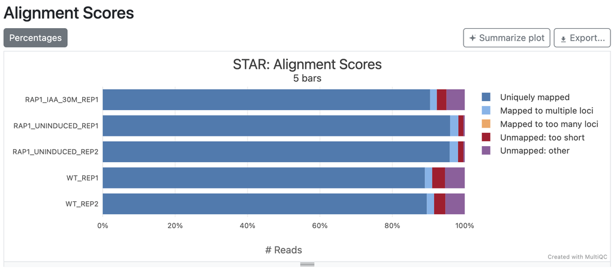

- The **gene count table** — this is used for downstream analysis such as differential expression analysis.

  ```bash
  ls -lh results/nfc-rnaseq/star_salmon/salmon.merged.gene_counts_length_scaled.tsv
  ```

  ```
  -rw-rw----+ 1 jelmer PAS0471 9.7K Oct 25 14:16 results/nfc-rnaseq/star_salmon/salmon.merged.gene_counts_length_scaled.tsv
  ```

  In the table, genes are in rows and samples in columns, and the values are the gene counts. These aren’t whole numbers, because Salmon *estimates* counts: for example, it splits a read that matches two genes equally well between them[^6].

  ```bash
  less -S results/nfc-rnaseq/star_salmon/salmon.merged.gene_counts_length_scaled.tsv
  ```

  ```
  gene_id             gene_name           RAP1_IAA_30M_REP1  RAP1_UNINDUCED_REP1  RAP1_UNINDUCED_REP2  WT_REP1           WT_REP2
  Gfp_transgene_gene  Gfp_transgene_gene  0                  0                    0                    0                 0
  HRA1                HRA1                0                  0                    0                    0                 0
  snR18               snR18               2.14802855661586   20.2855969463173     10.1375746973545     5.78423880944934  5.80768605222367
  tA(UGC)A            TGA1                0                  0                    0                    0                 0
  tL(CAA)A            SUP56               0                  0                    0                    0                 0
  tP(UGG)A            TRN1                0                  0                    0                    1.01841736490118  0
  tS(AGA)A            tS(AGA)A            1.01850122747957   0                    0                    0                 0
  YAL001C             TFC3                55.4778408610273   69.9211554832352     113.194248136096     60.4964254842457  30.2692589944609
  YAL002W             VPS8                36.3459924147924   32.4521250917071     80.5970831288856     63.580635210628   25.2482004816186
  YAL003W             EFB1                597.978458911117   888.742693215767     1857.82221206273     1049.55203167344  664.701066367987
  YAL004W             YAL004W             1.0197486986914    0                    0                    0                 1.01797117238891
  YAL005C             SSA1                6026.86373913046   6077.38491621524     12770.2053957157     7966.04370465683  4143.94126807027
  ```

In addition, the **`pipeline_info`** dir is useful for documenting your run: among other things, it has a file with all parameter settings that were used, a file with the versions of all software, and an execution report with the run time and memory usage of each step. When you publish results from the pipeline, cite both the pipeline and the tools it ran: the start of the log shows where to find these citations.

### 4.2 The `work` dir

The `work` dir contains sub-dirs in which all jobs ran, and where they produced their outputs before the pipeline copied a selection of them to the final output dir. Because it holds *all* outputs, including intermediate files, it is usually much larger than the final output dir.

For example, let’s compare the sizes of the final output dir and the work dir with the `du` command (these sizes can get *much* larger for real data runs):

```bash
du -sh results/nfc-rnaseq/ work
```

```
48M     results/nfc-rnaseq/
264M    work
```

**Tip`work` dir location**

In this case, `work` is in its default location, the dir from which you execute the `nextflow` command (i.e., the current working directory). For runs on real data, it’s best to put the `work` dir elsewhere, typically in `/fs/scratch`, which is faster and has more space than `/fs/ess` (we’ll do this in part II).

You won’t need to explore the `work` dir most of the time, but it can be useful for debugging or understanding the pipeline’s behavior and the exact commands that it ran. Let’s list its contents:

```bash
ls work
```

```
02  07  14  1e  23  2f  3b  47  51  5a  65  6e  78  81  8b  93  9e  a5  aa  b0  b7  c0  cf            d8  e6  ec  f7  singularity
03  08  15  1f  24  33  40  4b  52  5b  66  70  7a  82  8c  94  9f  a6  ab  b1  ba  c1  collect-file  d9  e8  ed  f8  stage-450f1767-7222-43e1-96cd-7d7b2a8a187c
04  0c  17  20  25  37  42  4c  55  5c  69  71  7b  83  8d  95  a1  a7  ad  b2  bc  c3  d2            db  e9  f1  fa  tmp
05  0f  1a  21  2c  38  43  4e  56  5d  6a  72  7c  86  90  9a  a3  a8  ae  b3  bd  c6  d3            e2  ea  f2  fb
06  11  1d  22  2e  3a  45  4f  59  63  6c  73  80  87  91  9d  a4  a9  af  b4  bf  ce  d7            e3  eb  f3  ff
```

How do you find your way around that? 😳 As mentioned above, the hexadecimal code at the start of each line in the log (e.g., `[2e/794b4b]`) points to the subdir of the work dir in which that job ran (every individual job runs in its own dir).

#### Self-study exercise: Explore the `work` dir of the MultiQC process

In this exercise, you’ll take a look at the `work` subdir of the pipeline’s final process: MultiQC.

1. Find the line for the MultiQC process in the pipeline’s log, and note its hexadecimal code.

   **Click for the solution**

   The line should look like this, though your hexadecimal code will be different (so use the one from your own log in the next steps):

   ```
   [2e/794b4b] NFCORE_RNASEQ:RNASEQ:MULTIQC_RNASEQ:MULTIQC (multiqc_report) [100%] 1 of 1 ✔
   ```

2. List all files in this process’s `work` subdir, including hidden files. Can you tell which are input files, which are output files, and what the hidden files might contain? *(Hint: the full name of the subdir is much longer than what’s shown in the log, but you can use a `*` wildcard to match the rest.)*

   **Click for the solution**

   Use the `-a` option to `ls` so hidden files are also listed:

   ```bash
   ls -a work/2e/794b4b*
   ```

   ```
   .    .command.err    .exitcode             versions.yml
   ..   .command.log    multiqc_config.yml
   1    .command.out    multiqc_report_data
   10   .command.run    multiqc_report.html
   100  .command.sh     multiqc_report_plots
   101  .command.begin  .command.trace  name_replacement.txt
   # [...Not all files shown...]
   ```

   The files in this `work` subdir include:
   - Input files (as links/shortcuts, so the files don’t have to be copied in full). Because MultiQC’s inputs come from many jobs and may have the same names, Nextflow puts each input file in its own numbered dir (`1`, `10`, `100`, etc.).
   - Output files, such as `multiqc_report.html`
   - Several hidden files, including:
     - `.command.sh`: the exact command that was run by this process
     - `.command.log`: logging information from the process run
3. Check exactly how MultiQC was run by the pipeline by looking at the `.command.sh` file.

   **Click for the solution**

   Show the contents of the `.command.sh` file:

   ```bash
   cat work/2e/794b4b*/.command.sh
   ```

   ```
   #!/usr/bin/env bash -C -e -u -o pipefail
   multiqc \
      --force \
      \
      --config 1/multiqc_config.yml --config 2/multiqc_sample_merge.yml \
      --filename multiqc_report.html \
      \
      --replace-names name_replacement.txt \
      \
      .
   # [...output truncated...]
   ```

   It can be good to know how exactly a program was run, for example to reproduce the command outside of Nextflow, for your methods section, or for troubleshooting.

## 5 Re-running a pipeline with `-resume`

When you rerun a pipeline with the `-resume` option, Nextflow checks for each job whether it was already successfully run before. It does so using a record of previous runs that it keeps in a hidden `.nextflow` dir. A job is skipped, and its earlier outputs reused, if:

- Its inputs, command, and settings are the same as in the previous run, and
- Its outputs are still present in the `work` dir

All other jobs are rerun, along with any downstream jobs that depend on their outputs. This saves a lot of time in situations like these:

- After a pipeline failed partway through, only the failed jobs and the jobs that depend on them are run.
- After you added samples or changed an input file, only the jobs for those samples or that file are run, plus jobs that combine all samples (like MultiQC).
- After you changed a setting that only affects the very last step, only that step is rerun.

Let’s quickly explore how the `-resume` option works. We’ll first remove the final output dir, and then re-run the same command as above, but now adding `-resume`:

```bash
rm -r results

nextflow run nf-core/rnaseq \
    -r 3.26.0 \
    -profile test,apptainer \
    --outdir results/nfc-rnaseq \
    --skip_qc \
    -resume
```

**Before running this: how long do you expect this run to take, and why?**

*The answer will be added after class.*

The process logging should look like this, where `cached: 1 ✔` (scroll to the right to see the full line) indicates that the outputs were already present from before, and the job wasn’t actually rerun:

```
[6b/1cecd9] NFCORE_RNASEQ:PREPARE_GENOME:GUNZIP_GTF (genes_with_empty_tid.gtf.gz)              [100%] 1 of 1, cached: 1 ✔
[f7/9413a8] NFCORE_RNASEQ:PREPARE_GENOME:CUSTOM_GTFFILTER (genes_with_empty_tid.filtered)      [100%] 1 of 1, cached: 1 ✔
[f1/6ca0de] NFCORE_RNASEQ:PREPARE_GENOME:GUNZIP_ADDITIONAL_FASTA (gfp.fa.gz)                   [100%] 1 of 1, cached: 1 ✔
[38/a41513] NFCORE_RNASEQ:PREPARE_GENOME:CUSTOM_CATADDITIONALFASTA (genome_transcriptome)      [100%] 1 of 1, cached: 1 ✔
[4e/47e489] NFCORE_RNASEQ:PREPARE_GENOME:EAUTILS_GTF2BED (genome_gfp)                          [100%] 1 of 1, cached: 1 ✔
[63/c4489b] NFCORE_RNASEQ:PREPARE_GENOME:SAMTOOLS_FAIDX (genome_gfp.fasta)                     [100%] 1 of 1, cached: 1 ✔
[b4/886567] NFCORE_RNASEQ:PREPARE_GENOME:BBMAP_BBSPLIT (null)                                  [100%] 1 of 1, cached: 1 ✔
[da/47c581] NFCORE_RNASEQ:PREPARE_GENOME:STAR_GENOMEGENERATE (genome_gfp.fasta)                [100%] 1 of 1, cached: 1 ✔
[b3/c2208a] NFCORE_RNASEQ:PREPARE_GENOME:UNTAR_SALMON_INDEX (salmon.tar.gz)                    [100%] 1 of 1, cached: 1 ✔
# [...output truncated...]
-[nf-core/rnaseq] Pipeline completed successfully -
Completed at: 25-Oct-2026 14:17:07
Duration    : 2m 32s
CPU hours   : 0.6 (94.9% cached)
Succeeded   : 5
Cached      : 157
```

**NoteIt still takes a few minutes, and a few jobs *may* be rerun**

The `-resume` run is not instantaneous, though, because Nextflow still has to check all jobs and copy the outputs to the final output dir. But it is clearly much faster than the first run, which actually ran all jobs. And for a real data run, the **time saved can be hours or days**.

You may also notice that not *all* jobs were cached: in the run above, 157 jobs were cached (`Cached: 157`), but 5 were rerun (`Succeeded: 5`). Such **“cache misses”** happen when Nextflow concludes that a job’s inputs may have changed, even though you didn’t change anything — for example, because a step received files from many jobs in a different order, or because an input file’s last-modified time changed. Downstream jobs that use the outputs of a rerun job are then rerun as well. A few cache misses like this are normal and nothing to worry about.

**What if you had instead rerun the pipeline with `-resume`, but without `--skip_qc`?**

*The answer will be added after class.*

**What if you had instead removed the `work` dir, and kept `results`, before rerunning with `-resume`?**

*The answer will be added after class.*

In part II, we will prepare the inputs for a run of the *rnaseq* pipeline on the Garrigós et al. (2025) data, and will run it via a Slurm batch job.

Back to top

## References

Di Tommaso, Paolo, Maria Chatzou, Evan W. Floden, Pablo Prieto Barja, Emilio Palumbo, and Cedric Notredame. 2017. “Nextflow enables reproducible computational workflows.” *Nature Biotechnology* 35 (4): 316–19. https://doi.org/10.1038/nbt.3820.

Ewels, Philip A., Alexander Peltzer, Sven Fillinger, et al. 2020. “The Nf-Core Framework for Community-Curated Bioinformatics Pipelines.” *Nature Biotechnology* 38 (3): 276–78. https://doi.org/10.1038/s41587-020-0439-x.

Garrigós, Marta, Guillem Ylla, Josué Martínez-de la Puente, Jordi Figuerola, and María José Ruiz-López. 2025. “Two Avian *Plasmodium* Species Trigger Different Transcriptional Responses on Their Vector *Culex pipiens*.” *Molecular Ecology* 34 (15): e17240. https://doi.org/10.1111/mec.17240.

## Footnotes

[^1]: As opposed to transcript-level counts, which are harder to accurately obtain with short-read data. Additionally, the pipeline only works when a reference genome is available, as it cannot do *de novo* transcriptome assembly.
[^2]: Typically, not all outputs are copied, especially for intermediate steps like read trimming — and pipelines have settings to determine what is copied.
[^3]: If we had wanted to run the *sarek* pipeline, for example, we would use `nf-core/sarek` instead.
[^4]: The most recent version, 3.27.0, requires a newer version of Nextflow than is available at OSC.
[^5]: Nextflow itself calls these “tasks”, which you’ll see in some of its messages. We’ll call them jobs, because in our real run, each will be a Slurm batch job.
[^6]: Additionally, as the file name indicates, the counts in this file have been “length-scaled”: adjusted for differences between samples in the average length of each gene’s expressed transcripts.